# Project: Investigate a Dataset (tmdb-movies dataset)

### Research Question 2 (Movies that has the Most and Least popularity)

```python
# Here we are calculating the Movies that has the most and least popularity
# This is calculated by the same 'do' function that we created earlier
do('popularity')
```

|  | 0 | 7268 |
| --- | --- | --- |
| id | 135397 | 1392 |
| popularity | 32.9858 | 0.001117 |
| budget | 1.5e+08 | 350000 |
| revenue | 1.51353e+09 | 3.51506e+06 |
| original_title | Jurassic World | Born into Brothels |
| runtime | 1970-01-01 00:00:00.000000124 | 1970-01-01 00:00:00.000000085 |
| release_date | 6/9/15 | 12/8/04 |
| vote_count | 5562 | 23 |
| vote_average | 6.5 | 6.4 |
| release_year | 2015 | 2004 |
| budget_adj | 1.38e+08 | 404056 |
| revenue_adj | 1.39245e+09 | 4.05795e+06 |

### Research Question 3 (Movies wtih Highest and Lowest runtime)

```python
# Here we are calcuating the highest and lowest runtime of the given movies in the dataset
# The same 'do' function is used for this calculation
do('runtime')
```

|  | 2107 | 5162 |
| --- | --- | --- |
| id | 43434 | 24914 |
| popularity | 0.534192 | 0.208637 |
| budget | 1.8e+07 | 10 |
| revenue | 871279 | 5 |
| original_title | Carlos | Kid's Story |
| runtime | 1970-01-01 00:00:00.000000338 | 1970-01-01 00:00:00.000000015 |
| release_date | 5/19/10 | 6/2/03 |
| vote_count | 35 | 16 |
| vote_average | 6.2 | 6.8 |
| release_year | 2010 | 2003 |
| budget_adj | 1.8e+07 | 11.8535 |
| revenue_adj | 871279 | 5.92676 |

### Research Question 4 (Movies wtih Highest and Lower Profit Earned)

```python
# We want to calculate the highest and lowest of profit earned by a movie
# First we subtract the budget amount from the revenue amount
df['profit'] = df['revenue'] - df['budget']
# Then using the 'do' funtion we calculate the highest and lowest profit earned
do('profit')
```

[output not shown]

```python
cast_data = df['cast'].str.cat(sep = '|') # Here we separate each cast name from each movie which are separated by '|'
cast_data_2 = pd.Series(cast_data.split('|'))
count = cast_data_2.value_counts(ascending = False)# Here we count the number of times each cast appeared in each movie
count.head(5)# this displays the Top 5 most recruited cast
```

[output not shown]

```python
cast_data = df['director'].str.cat(sep = '|')# Here we separate each cast name from each movie which are separated by '|'
cast_data_2 = pd.Series(cast_data.split('|'))
count = cast_data_2.value_counts(ascending = False)# Here we count the number of times each cast appeared in each movie
count.head(5)# This displays the top 5 most recruited directors
```

[output not shown]

```python
cast_data = df['genres'].str.cat(sep = '|')# Here we separate each genre name from each movie which are separated by '|'
cast_data_2 = pd.Series(cast_data.split('|'))
count = cast_data_2.value_counts(ascending = False)# Here we count what type of genre is each movie
count.head(5) # This displays the top 5 genres
```

[output not shown]

### Research Question 7 (Average Budget)

```python
# This code calculates the mean or the average of the budget column
df['budget'].mean()
```

```
37203696.954852104
```

Visualization of the above code

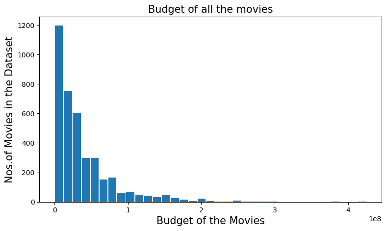

```python
#plotting a histogram of Budget for movies

#giving the figure size(width, height)
plt.figure(figsize=(9,5), dpi = 100)

#On x-axis
plt.xlabel('Budget of the Movies', fontsize = 15)
#On y-axis
plt.ylabel('Nos.of Movies in the Dataset', fontsize=15)
#Name of the graph
plt.title('Budget of all the movies', fontsize=15)

#giving a histogram plot
plt.hist(df['budget'], rwidth = 0.9, bins =35)
#displays the plot
plt.show()
```

From the above graph it is clear that it is a positively skewed graph.

### Research Question 8 (Average Runtime)

```python
# This code calculates the mean or the average of the runtime column
df['runtime'].mean()
```

[output not shown]

Visualization of the above code

[figure not shown]

```python
#plotting a histogram of runtime of movies

#giving the figure size(width, height)
plt.figure(figsize=(9,5), dpi = 100)

#On x-axis
plt.xlabel('Runtime of the Movies', fontsize = 15)
#On y-axis
plt.ylabel('Nos.of Movies in the Dataset', fontsize=15)
#Name of the graph
plt.title('Runtime of all the movies', fontsize=15)

#giving a histogram plot
plt.hist(df['runtime'], rwidth = 0.9, bins =35)
#displays the plot
plt.show()
```

From the above graph it is clear that it is a positively skewed graph.The most values fall between the range of 90 to 110 for most of the movies

[figure not shown]

```python
import seaborn as sns
#This plot is the box plot of the runtime of the movies
plt.figure(figsize=(9,7), dpi = 105)

#using seaborn to generate the boxplot
sns.boxplot(df['runtime'], linewidth = 3)
#diplaying the plot
plt.show()
```

This graphical visualization helps us to identify the outliers in the runtime column.

# Research Question 9: Year of release vs Profitability

[figure not shown]

```python
#Here we are using line plot to represent our analysis
profits_year = df.groupby('release_year')['profit'].sum()# here we are grouping by

#figure size(width, height)
plt.figure(figsize=(12,6), dpi = 130)

plt.xlabel('Release Year of Movies in the data set', fontsize = 12)# Here we are specifing label for x axis
plt.ylabel('Profits earned by Movies', fontsize = 12)# Here we are specifing label for y axis
plt.title('Total Profits earned  Vs Year of release.')# Here we are giving a title name for our plot
plt.plot(profits_year)

plt.show()# this shows the output of the plot
```

[figure not shown]

```python
#Here we are using a histogram to represent our above analysis in another format
profits_year = df.groupby('release_year')['profit'].sum()# here we are grouping by

#figure size(width, height)
plt.figure(figsize=(12,6), dpi = 130)

plt.xlabel('Release Year of Movies in the data set', fontsize = 12)# Here we are specifing label for x axis
plt.ylabel('Profits earned by Movies', fontsize = 12)# Here we are specifing label for y axis
plt.title('Total Profits earned  Vs Year of release.')# Here we are giving a title name for our plot
plt.hist(profits_year)

plt.show()# this shows the output of the plot
```

## Conclusions

# Limitations :

Though we were able to come to a conclusion by analysing the given data still the data may not be purely error free There might be some errors like for example the budget and revenue column did not have any currency mentioned hence they might be in dollars,euros or ruppees which depends upon the country for which the movies where released so not mentionin the country name was also an error.Dropping certain unwanted rows and columns might as well as affected our analysis.We also dropped duplicate rows and columns which could have been the same above released in different coutries.Hence the above analysis is Wrong. So the above given Criteria may or may not work.